# PCA project 2 DAT 402

## PCA Project 2: Stock Data using PCA

### DAT 402

### By Robert Lee

Problem: When we turn to stock data to make investments, we find ourselves lost and unsure about trends and patterns. How can we get a better understanding of the market and identify potential opportunities? The stock market is very complex and changing. Finding patterns and figuring out principle components can help us understand the market and make better decisions.

Goals: Identify common patterns and correlations across major stock prices using PCA

Method:

- I will analyze stock data for 5 major companies: Apple, Microsoft, Google, Amazon, and Tesla.
- I will use the yfinance library to download historical stock data for these companies from 2020-01-01 to 2023-01-01.

More info: The yfinance library is a Python library for downloading stock market data from Yahoo Finance. It provides a simple and easy-to-use interface to access stock data and financial information.

Analyzing data from 2020 on these companies will maybe even give us insights on pandemics affects and how these companies bounced back.

```python
import pandas as pd
import numpy as np
import matplotlib.pyplot as plt
import seaborn as sns
from sklearn.model_selection import train_test_split
from sklearn.linear_model import LogisticRegression
from sklearn.preprocessing import StandardScaler
from sklearn.decomposition import PCA
from sklearn.metrics import precision_recall_curve
from sklearn.metrics import roc_curve, auc
from sklearn.metrics import accuracy_score, classification_report, confusion_matrix
from sklearn.model_selection import GridSearchCV
from sklearn.metrics import mean_squared_error, r2_score
from sklearn.cluster import KMeans


import yfinance as yf
```

### Step 1: Data Collection:

```python
# Define the stock symbols and date range
stocks = ['AAPL', 'MSFT', 'GOOGL', 'AMZN', 'TSLA']
start_date = '2020-01-01'
end_date = '2023-01-01'

# Download
stock_data = yf.download(stocks, start=start_date, end=end_date)
print(stock_data)

# Save to CSV for future use
stock_data.to_csv('stock_data.csv')
```

```
[*********************100%***********************]  5 of 5 completed
```

```
Price                       Adj Close                                    \
Ticker                           AAPL       AMZN      GOOGL        MSFT
Date
2020-01-02 00:00:00+00:00   72.796028  94.900497  68.264961  153.630722
2020-01-03 00:00:00+00:00   72.088295  93.748497  67.907845  151.717712
2020-01-06 00:00:00+00:00   72.662697  95.143997  69.717865  152.109894
2020-01-07 00:00:00+00:00   72.320976  95.343002  69.583206  150.722992
2020-01-08 00:00:00+00:00   73.484352  94.598503  70.078476  153.123764
...                               ...        ...        ...         ...
2022-12-23 00:00:00+00:00  130.487793  85.250000  89.009598  234.875427
2022-12-27 00:00:00+00:00  128.676849  83.040001  87.174141  233.134018
2022-12-28 00:00:00+00:00  124.728363  81.820000  85.807526  230.743225
2022-12-29 00:00:00+00:00  128.261215  84.180000  88.231522  237.118622
2022-12-30 00:00:00+00:00  128.577911  84.000000  88.012070  235.947830

Price                                       Close                        \
Ticker                           TSLA        AAPL       AMZN      GOOGL
Date
2020-01-02 00:00:00+00:00   28.684000   75.087502  94.900497  68.433998
2020-01-03 00:00:00+00:00   29.534000   74.357498  93.748497  68.075996
2020-01-06 00:00:00+00:00   30.102667   74.949997  95.143997  69.890503
2020-01-07 00:00:00+00:00   31.270666   74.597504  95.343002  69.755501
2020-01-08 00:00:00+00:00   32.809334   75.797501  94.598503  70.251999
...                               ...         ...        ...        ...
2022-12-23 00:00:00+00:00  123.150002  131.860001  85.250000  89.230003
2022-12-27 00:00:00+00:00  109.099998  130.029999  83.040001  87.389999
2022-12-28 00:00:00+00:00  112.709999  126.040001  81.820000  86.019997
2022-12-29 00:00:00+00:00  121.820000  129.610001  84.180000  88.449997
2022-12-30 00:00:00+00:00  123.180000  129.929993  84.000000  88.230003

Price                                              ...        Open             \
Ticker                           MSFT        TSLA  ...        AAPL       AMZN
Date                                               ...
2020-01-02 00:00:00+00:00  160.619995   28.684000  ...   74.059998  93.750000
2020-01-03 00:00:00+00:00  158.619995   29.534000  ...   74.287498  93.224998
2020-01-06 00:00:00+00:00  159.029999   30.102667  ...   73.447502  93.000000
2020-01-07 00:00:00+00:00  157.580002   31.270666  ...   74.959999  95.224998
2020-01-08 00:00:00+00:00  160.089996   32.809334  ...   74.290001  94.902000
...                               ...         ...  ...         ...        ...
2022-12-23 00:00:00+00:00  238.729996  123.150002  ...  130.919998  83.250000
```

[output cut: 21 more lines]

```
Ticker                         AMZN     GOOGL      MSFT       TSLA
Date
2020-01-02 00:00:00+00:00  80580000  27278000  22622100  142981500
2020-01-03 00:00:00+00:00  75288000  23408000  21116200  266677500
2020-01-06 00:00:00+00:00  81236000  46768000  20813700  151995000
2020-01-07 00:00:00+00:00  80898000  34330000  21634100  268231500
2020-01-08 00:00:00+00:00  70160000  35314000  27746500  467164500
...                             ...       ...       ...        ...
2022-12-23 00:00:00+00:00  57433700  23003000  21207000  166989700
2022-12-27 00:00:00+00:00  57284000  20097300  16688600  208643400
2022-12-28 00:00:00+00:00  58228600  19523200  17457100  221070500
2022-12-29 00:00:00+00:00  54995900  23333500  19770700  221923300
2022-12-30 00:00:00+00:00  62401200  23986300  21938500  157777300

[756 rows x 30 columns]
```

### Step 2: Data Preprocessing

```python
# Data Cleaning
returns = stock_data['Adj Close'].pct_change().dropna()
```

```python
# Focusing on adjusted close prices
adj_close_data = stock_data['Adj Close']
```

### Step 3: Explorary Data Analysis

```python
print(adj_close_data.describe())
```

```
Ticker        AAPL        AMZN       GOOGL        MSFT        TSLA
count   756.000000  756.000000  756.000000  756.000000  756.000000
mean    127.940988  142.455482  104.000134  238.859865  206.365502
std      30.494847   27.856019   26.407481   47.356441   95.856975
min      54.509758   81.820000   52.576313  129.881027   24.081333
25%     112.981405  118.337875   78.026913  204.823357  138.270828
50%     133.331627  154.467499  104.015438  239.862099  223.651665
75%     148.579090  164.633247  126.669222  276.641098  276.565002
max     179.076599  186.570496  149.468399  334.436371  409.970001
```

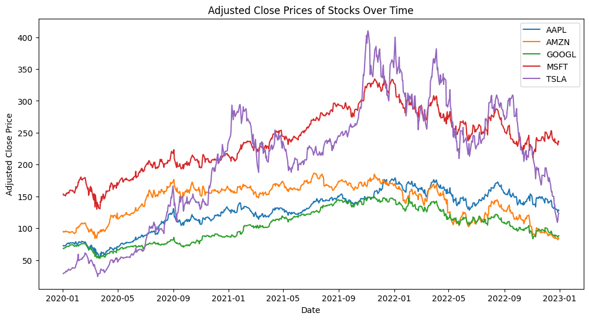

```python
# Stock Prices Stock Plot
plt.figure(figsize=(12, 6))
for column in adj_close_data.columns:
    plt.plot(adj_close_data.index, adj_close_data[column], label=column)
plt.xlabel('Date')
plt.ylabel('Adjusted Close Price')
plt.title('Adjusted Close Prices of Stocks Over Time')
plt.legend()
plt.show()
```

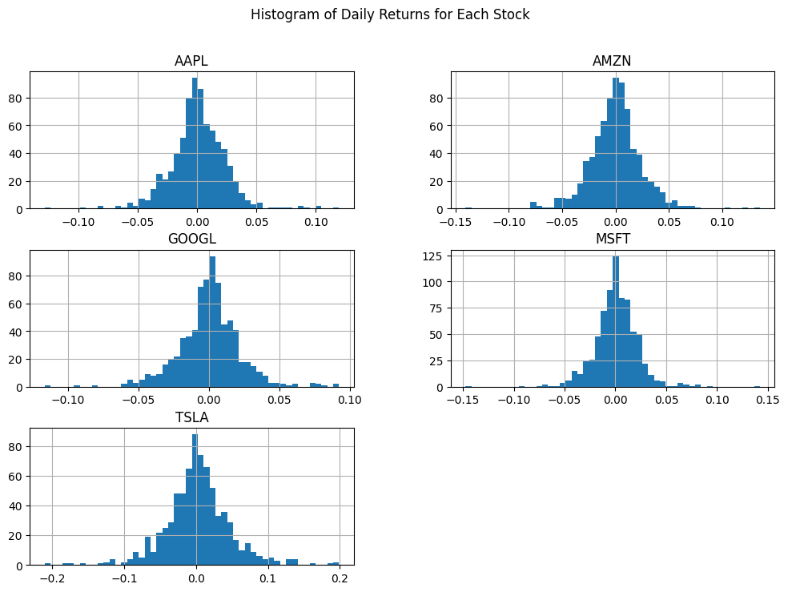

```python
returns = adj_close_data.pct_change().dropna()
returns.hist(bins=50, figsize=(12, 8))
plt.suptitle('Histogram of Daily Returns for Each Stock')
plt.show()
```

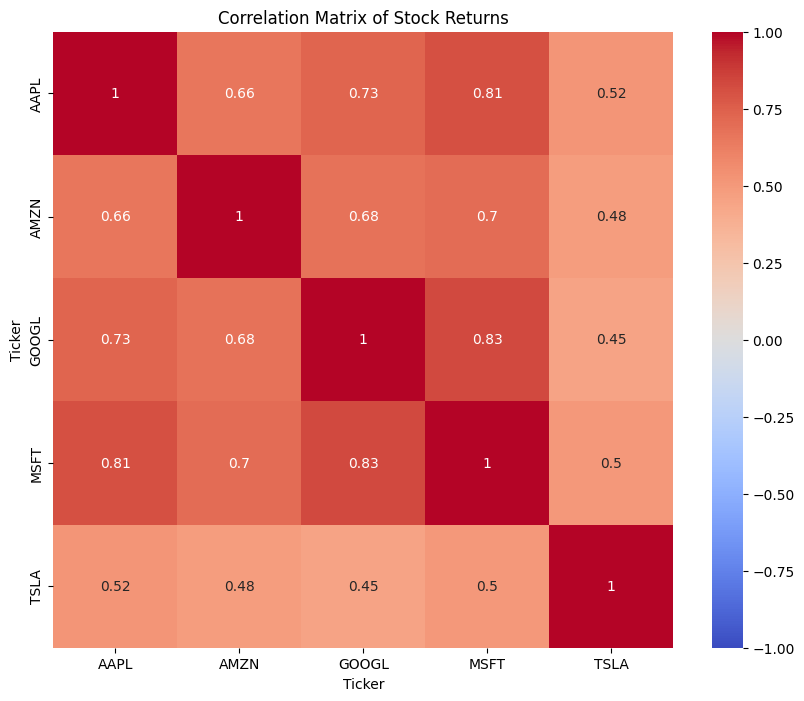

```python
# Correlation heatmap
plt.figure(figsize=(10, 8))
sns.heatmap(returns.corr(), annot=True, cmap='coolwarm', vmin=-1, vmax=1)
plt.title('Correlation Matrix of Stock Returns')
plt.show()
```

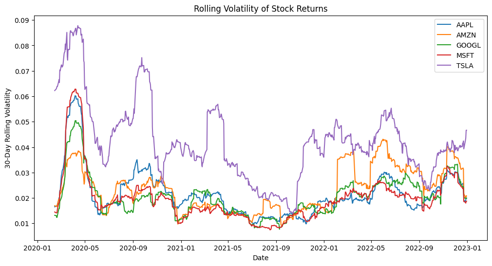

```python
# rolling volatility: variability of returns
rolling_volatility = returns.rolling(window=30).std()

plt.figure(figsize=(12, 6))
for column in rolling_volatility.columns:
    plt.plot(rolling_volatility.index, rolling_volatility[column], label=column)
plt.xlabel('Date')
plt.ylabel('30-Day Rolling Volatility')
plt.title('Rolling Volatility of Stock Returns')
plt.legend()
plt.show()
```

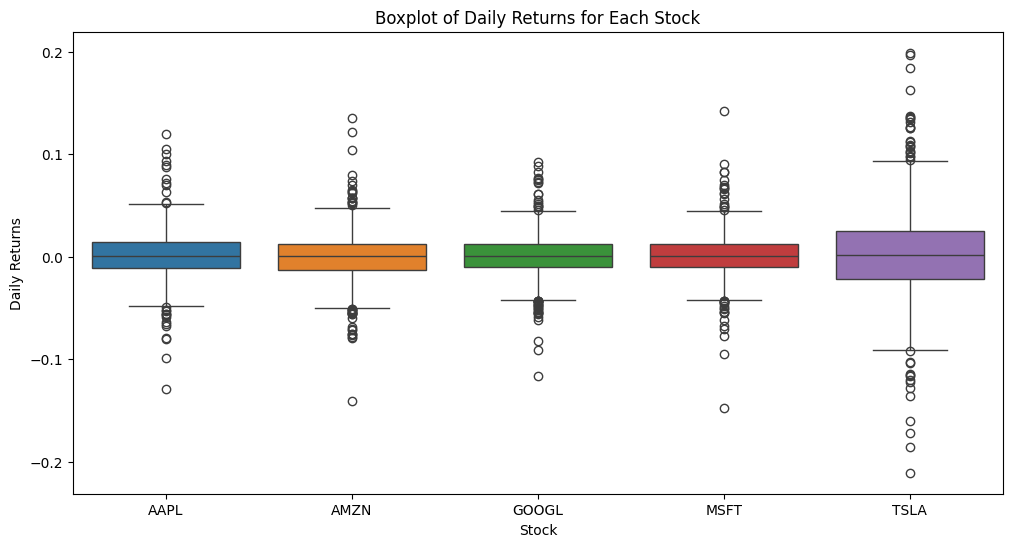

```python
plt.figure(figsize=(12, 6))
sns.boxplot(data=returns)
plt.title('Boxplot of Daily Returns for Each Stock')
plt.xlabel('Stock')
plt.ylabel('Daily Returns')
plt.show()
```

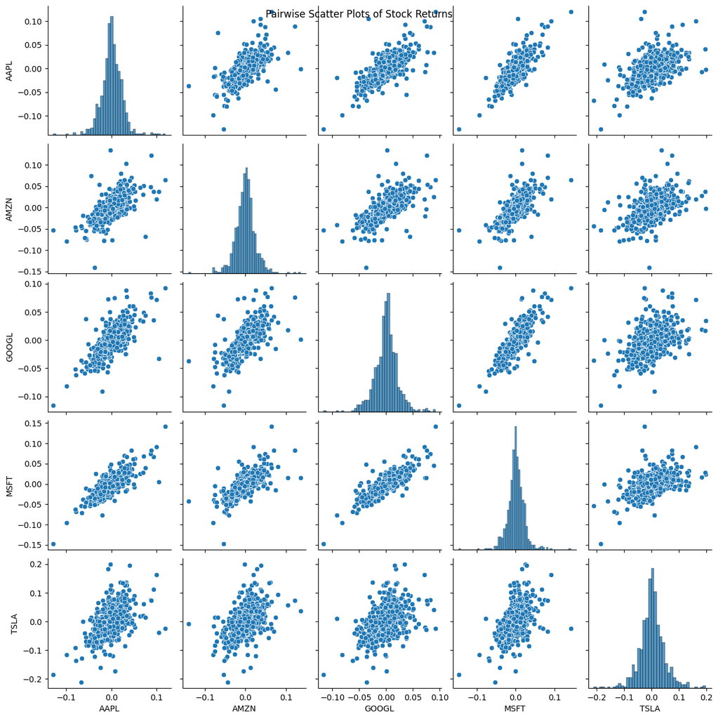

```python
sns.pairplot(returns)
plt.suptitle('Pairwise Scatter Plots of Stock Returns')
plt.show()
```

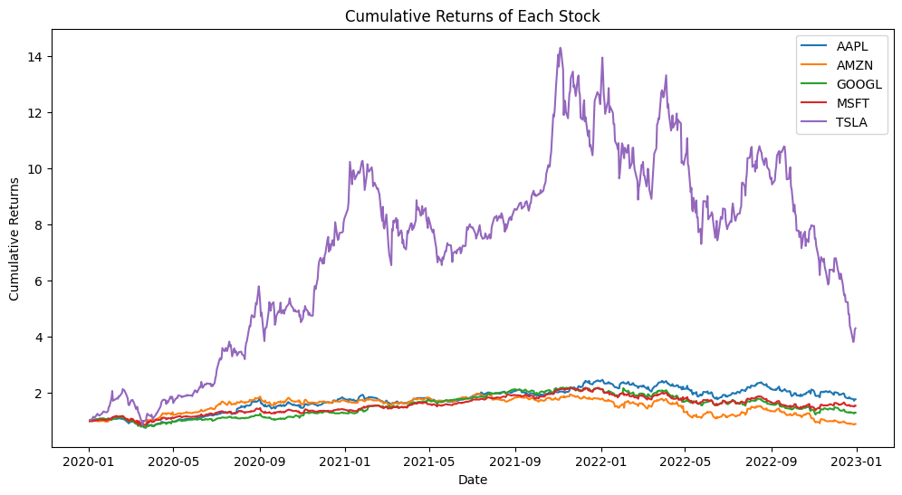

```python
cumulative_returns = (1 + returns).cumprod()

plt.figure(figsize=(12, 6))
for column in cumulative_returns.columns:
    plt.plot(cumulative_returns.index, cumulative_returns[column], label=column)
plt.xlabel('Date')
plt.ylabel('Cumulative Returns')
plt.title('Cumulative Returns of Each Stock')
plt.legend()
plt.show()
```

### Step 4: Principal Component Analysis

```python
# Calculate daily returns as percentage change
returns = adj_close_data.pct_change().dropna()
```

```python
# Standardize returns data
scaler = StandardScaler()
returns_scaled = scaler.fit_transform(returns)
```

```python
# Apply PCA
pca = PCA(n_components=0.9)
returns_pca = pca.fit_transform(returns_scaled)

print("Explained variance ratios:", pca.explained_variance_ratio_)
```

```
Explained variance ratios: [0.71606081 0.12788136 0.07393886]
```

```python
# Initialize PCA with 2 components
pca = PCA(n_components = 2)
returns_pca = pca.fit_transform(returns_scaled)

# Reconstruct using selected components
reconstructed_data = pca.inverse_transform(returns_pca)
```

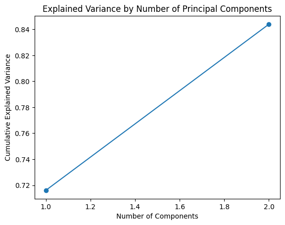

```python
plt.plot(range(1, len(pca.explained_variance_ratio_) + 1),
         pca.explained_variance_ratio_.cumsum(), marker='o')
plt.xlabel('Number of Components')
plt.ylabel('Cumulative Explained Variance')
plt.title('Explained Variance by Number of Principal Components')
plt.show()
```

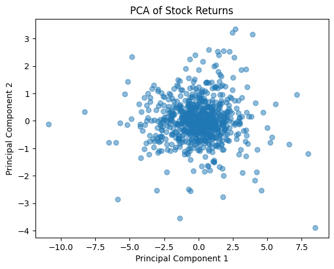

```python
# Scatter plot of the first two principal components
plt.scatter(returns_pca[:, 0], returns_pca[:, 1], alpha=0.5)
plt.xlabel('Principal Component 1')
plt.ylabel('Principal Component 2')
plt.title('PCA of Stock Returns')
plt.show()
```